# Overwatch Esports Team Performance Analysis

Grant Gabrie

2025-10-28

# Introduction

This project analyzes performance statistics from the Bowling Green State University Overwatch varsity team during the Fall 2025 season. The dataset records each player’s in-game performance across multiple matches, maps, and opponents.

The purpose of this analysis is to: - Explore win rates across different maps. - Examine the relationship between damage and healing for our support players, Reinfardt and Hobo. - Calculate Kill/Death (KD) ratios to identify player consistency, Map Wins and Losses.

# Data Description

```r
library(dplyr)
```

```r
library(ggplot2)
library(tidyr)
library(knitr)

# Load dataset
data <- read.csv("Overwatch Season Stat Tracker(Raw Match Data) (6).csv")

# Clean numeric columns (remove commas)
cols_to_fix <- c("Damage.Dealt", "Healing.Done", "Damage.Mitigated")
data[cols_to_fix] <- lapply(data[cols_to_fix], function(x) as.numeric(gsub(",", "", x)))

# Remove unnecessary columns. I had plans for more data, but decided it would have been too much
data <- subset(data, select = -c(Final.Blows, Ultimates.Used, Ultimates.Earned))

# Remove NA rows
data <- na.omit(data)
```

# Map Win Analysis

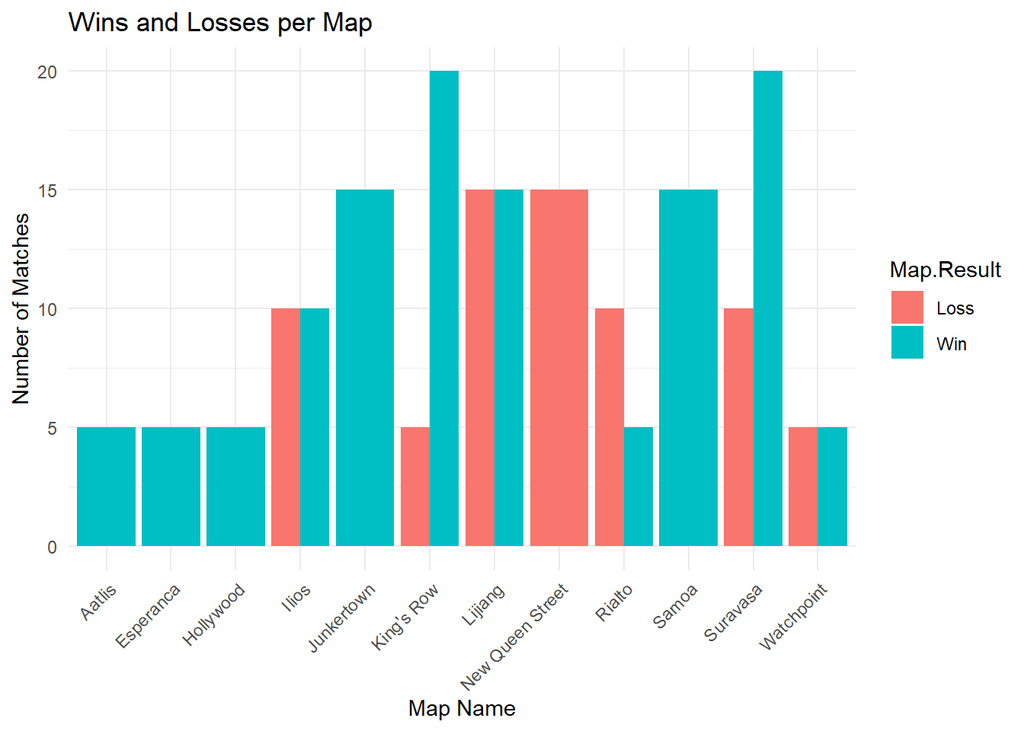

```r
map_results <- data %>%
  group_by(Map.Name, Map.Result) %>%
  summarise(Games = n(), .groups = 'drop')

ggplot(map_results, aes(x = Map.Name, y = Games, fill = Map.Result)) +
  geom_bar(stat = "identity", position = "dodge") +
  labs(title = "Wins and Losses per Map", x = "Map Name", y = "Number of Matches") +
  theme_minimal() +
  theme(axis.text.x = element_text(angle = 45, hjust = 1))
```

This code block analyzes the team’s performance across different maps. It groups the data by map name and map result (Win/Loss) and then counts the number of games for each combination. The ggplot function then creates a bar chart visualizing these wins and losses side-by-side for each map, making it easy to see which maps the team performed well on and which were more challenging.

# Damage Distribution per Player

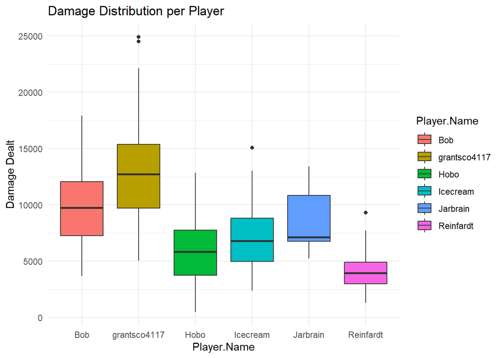

```r
ggplot(data, aes(x = `Player.Name`, y = `Damage.Dealt`, fill = `Player.Name`)) +
  geom_boxplot() +
  labs(title = "Damage Distribution per Player", y = "Damage Dealt") +
  theme_minimal()
```

Here, we visualize the distribution of damage dealt by each player. A boxplot is generated using ggplot to show the median, quartiles, and potential outliers for each player’s damage output across all matches. This helps identify which players are consistently high-damage dealers and shows the variance in their performance.

# K/D Ratio by Player

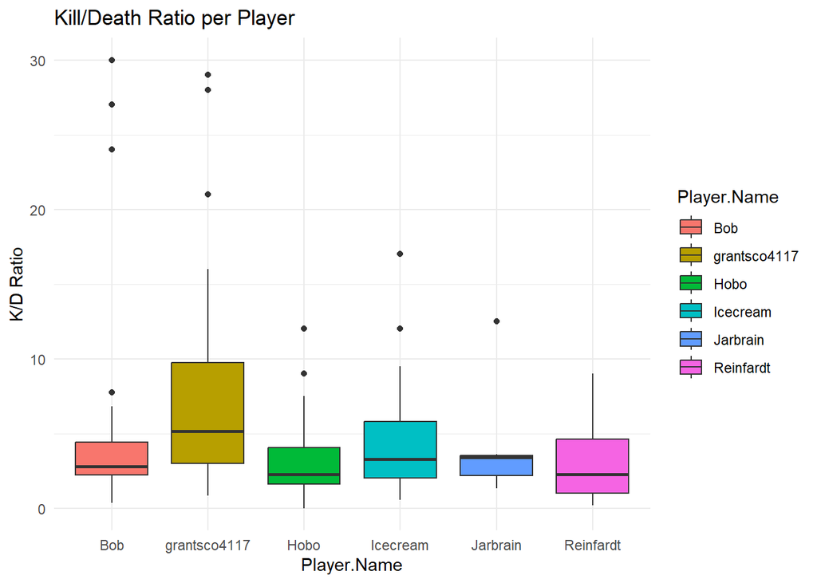

```r
ggplot(data, aes(x = `Player.Name`, y = Eliminations / Deaths, fill = `Player.Name`)) +
  geom_boxplot() +
  labs(title = "Kill/Death Ratio per Player", y = "K/D Ratio") +
  theme_minimal()
```

# Relationship Between Damage and Healing

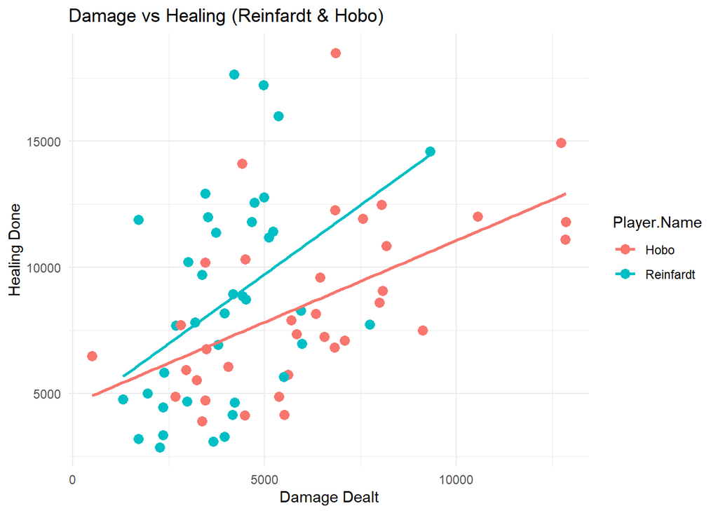

```r
rh <- data %>% filter(Player.Name %in% c("Reinfardt", "Hobo"))

ggplot(rh, aes(x = Damage.Dealt, y = Healing.Done, color = Player.Name)) +
  geom_point(size = 3) +
  geom_smooth(method = "lm", se = FALSE) +
  labs(title = "Damage vs Healing (Reinfardt & Hobo)", x = "Damage Dealt", y = "Healing Done") +
  theme_minimal()
```

```r
# Correlation
correlation <- cor(rh$Damage.Dealt, rh$Healing.Done)
correlation
```

```
## [1] 0.4257319
```

This analysis focuses specifically on the support/tank players ‘Reinfardt’ and ‘Hobo’ to examine the relationship between their damage and healing. The code first filters for only these two players. Then, it creates a scatter plot with ggplot to map ‘Damage.Dealt’ (x-axis) against ‘Healing.Done’ (y-axis), adding a linear regression line (geom_smooth) to show the trend for each player. Finally, it calculates the Pearson correlation coefficient (cor) to quantify the strength and direction of this relationship.

# Healing vs. Damage

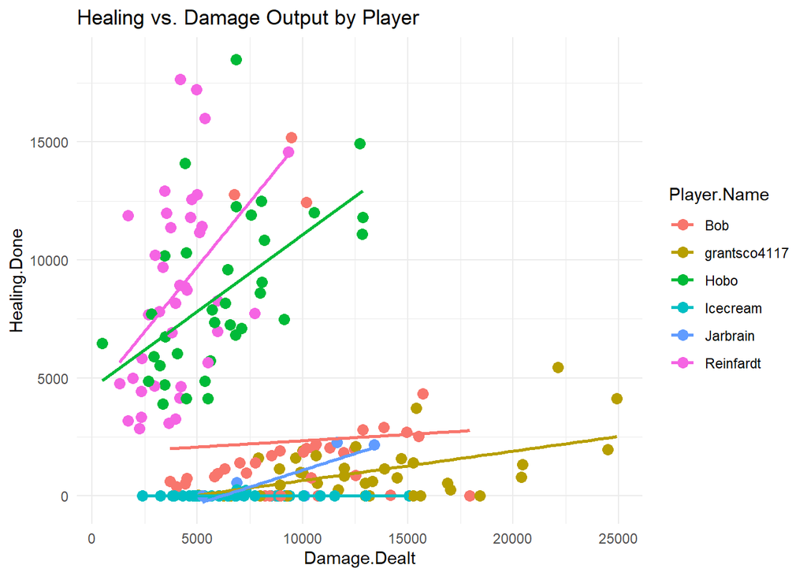

```r
ggplot(data, aes(x = `Damage.Dealt`, y = `Healing.Done`, color = `Player.Name`)) +
  geom_point(size = 3) +
  geom_smooth(method = "lm", se = FALSE) +
  labs(title = "Healing vs. Damage Output by Player") +
  theme_minimal()
```

This scatter plot visualizes the relationship between damage dealt and healing done for all players on the team. While the previous plot focused only on Reinfardt and Hobo, this one includes everyone, with points colored by player name and a regression line showing the general trend for each. This helps identify player roles (e.g., high damage/low heal, high heal/low damage, or hybrids) across the entire roster.

# Player Comparisons

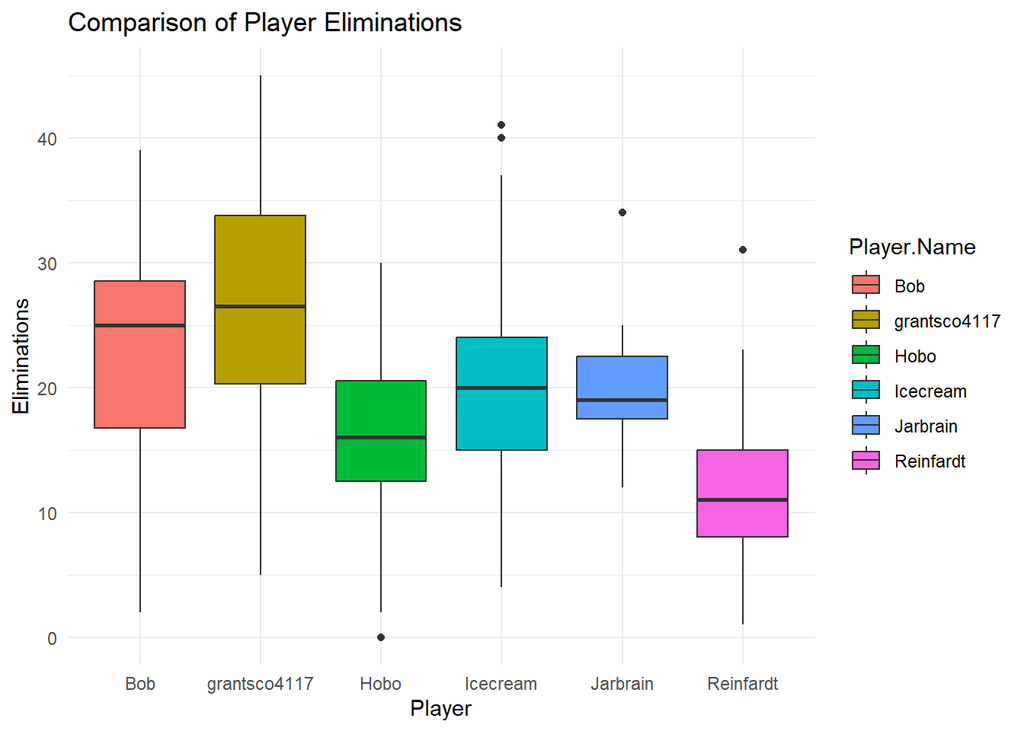

```r
ggplot(data, aes(x = Player.Name, y = Eliminations, fill = Player.Name)) +
  geom_boxplot() +
  labs(title = "Comparison of Player Eliminations", x = "Player", y = "Eliminations") +
  theme_minimal()
```

This plot provides a direct comparison of total eliminations across all players. Using a boxplot, it visualizes the distribution (median, spread, and outliers) of eliminations for each player, offering another perspective on player offensive performance and consistency, similar to the K/D ratio plot.

# Conclusion

This analysis provided several insights into the BGSU Overwatch team’s Fall 2025 season performance.

Map Performance: The “Wins and Losses per Map” chart highlights that team performance varied significantly by map. Identifying the maps with lower win rates presents a clear opportunity for targeted practice and strategy refinement.

Player Roles and Consistency: The boxplots for “Damage Distribution” and “K/D Ratio” help quantify player roles and consistency. We can see which players are the team’s primary damage dealers and which players are most efficient at securing eliminations relative to their deaths. The “Comparison of Player Eliminations” plot further reinforces these findings, showing the general offensive output of each team member.

Support Dynamics: The focused analysis of “Reinfardt” and “Hobo” revealed the specific nature of their damage-to-healing relationship. The calculated correlation (printed in the chunk) quantifies this, suggesting how they balance aggressive play with protective duties.

Team-Wide Roles: The final “Healing vs. Damage” scatter plot for all players clearly visualizes the different roles on the team, distinguishing high-damage players from high-healing players and those who contribute in both categories.

Overall, this analysis successfully identified player strengths, role specializations, and map-specific team performance. These insights can be valuable for coaching staff and players to understand performance patterns and guide future training.